# Analysis of Gazi bay eDNA data

Generate NMDS and view it;

```r
set.seed(123)
nmds <- metaMDS(m_data, k = 5, trymax = 100, distance = "bray")
```

```
Square root transformation
Wisconsin double standardization
*** Solution reached
```

```r
nmds
```

```
Call:
metaMDS(comm = m_data, distance = "bray", k = 5, trymax = 100)

global Multidimensional Scaling using monoMDS

Data:     wisconsin(sqrt(m_data))
Distance: bray

Dimensions: 5
Stress:     0.03653513
Stress type 1, weak ties
Two convergent solutions found after 20 tries
Scaling: centring, PC rotation, halfchange scaling
Species: expanded scores based on ‘wisconsin(sqrt(m_data))’
```

Calling your nmds object in R, will give you some information about your analysis. An important number to note is the stress, which is roughly the “goodness of fit” of your NMDS ordination. For a good representation of your data, the stress value should ideally be less than 0.2. If the stress value is 0, it might mean you have an outlier sample that is very different than all your other samples. Depending on your question, you may want to remove this sample to observe any other underlying patterns in your data.Stress values >0.2 are generally poor and potentially uninterpretable, whereas values <0.1 are good and <0.05 are excellent, leaving little danger of misinterpretation. Stress values between 0.1 and 0.2 are useable but some of the distances will be misleading. The stress value should be reported somewhere in your figure or figure caption. My stress value for this analysis is 0.03653513.

Create a Stressplot

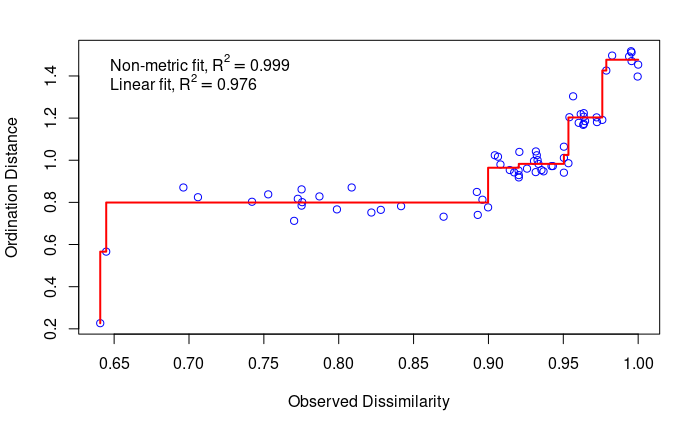

```r
stressplot(nmds)
```

Create a simple NMDS plot in base R;

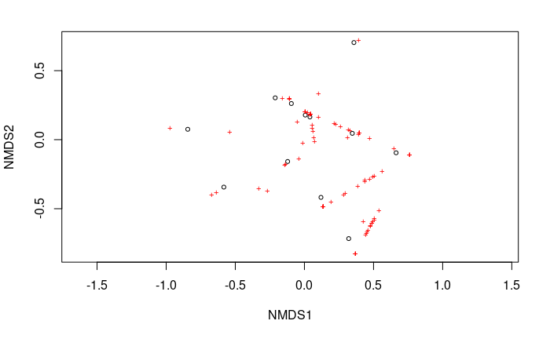

```r
plot(nmds)
```

The plot does not give any meaningful information. The circles represent samples while the red stars represent species. From here we will be using **ggplot2** for nice figures;

First, I obtained the coordinates for NMDS1 and NMDS2 axes and put them in a new data frame (data.scores)

```r
#extract NMDS scores (x and y coordinates)
data.scores <- as.data.frame(scores(nmds))
```

then I added columns with environmental data (Site, Replicate and Habitat) to my new data frame(data.scores).

```r
#add columns to data frame
data.scores$Site = st_df$Site
data.scores$Replicate = st_df$Replicate
data.scores$Habitat = st_df$Habitat

head(data.scores)
```

[output not shown]

Create an NMDS plot using ggplot2

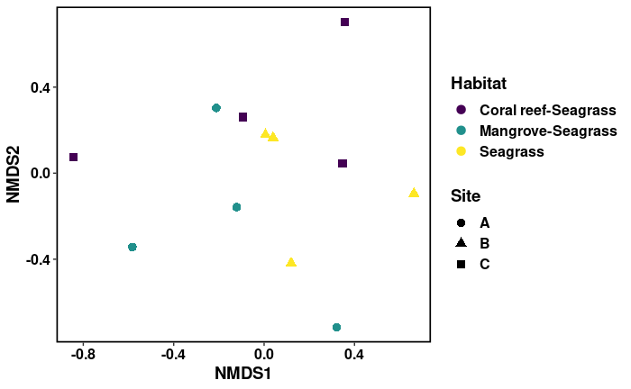

```r
library(ggplot2)

ggplot(data.scores, aes(x = NMDS1, y = NMDS2)) +
    geom_point(size = 3, aes( shape = Site, colour = Habitat))+
    theme(axis.text.y = element_text(colour = "black", size = 12, face = "bold"),
    axis.text.x = element_text(colour = "black", face = "bold", size = 12),
    legend.text = element_text(size = 12, face ="bold", colour ="black"),
    legend.position = "right", axis.title.y = element_text(face = "bold", size = 14),
    axis.title.x = element_text(face = "bold", size = 14, colour = "black"),
    legend.title = element_text(size = 14, colour = "black", face = "bold"),
    panel.background = element_blank(), panel.border = element_rect(colour = "black", fill = NA, size = 1.2),
    legend.key=element_blank()) +
    labs(x = "NMDS1", colour = "Habitat", y = "NMDS2", shape = "Site")  +
    scale_colour_viridis_d(alpha = 1, begin = 0, end = 1, direction = 1, option = "D", aesthetics = "colour")
```

From the plot I observed a distinction in my sample replicates and site with some replicates clustering at the center which is an indication that they contain some similar species. First we need to extract the relevant information from nmds and envfit results.I extracted Sample coordinates in NMDS ordination space.

```r
data.scores <- as.data.frame(scores(nmds))
data.scores$Habitat <- env_df$Habitat
```

```r
en_coord_cont <- as.data.frame(scores(en, "vectors")) * ordiArrowMul(en)
en_coord_cat <- as.data.frame(scores(en, "factors")) * ordiArrowMul(en)
```

To add species distribution to the plot, I fit the species vector;

```r
data.spp.fit <- envfit(nmds, df, permutations = 999) # this fits species vectors
```

then transform species data into vectors and list p values

```r
spp.scrs <- as.data.frame(scores(data.spp.fit, display = "vectors")) #save species intrinsic values into dataframe
spp.scrs <- cbind(spp.scrs, Species = rownames(spp.scrs)) #add species names to dataframe
spp.scrs <- cbind(spp.scrs, pval = data.spp.fit$vectors$pvals) #add pvalues to dataframe so you can select species which are significant
spp.scrs<- cbind(spp.scrs, abrev = abbreviate(spp.scrs$Species, minlength = 6)) #abbreviate species names
sig.spp.scrs <- subset(spp.scrs, pval<=0.05) #subset data to show species significant at 0.05

spp.scrs
```

|  | NMDS1 | NMDS2 | Species | pval | abrev |
| --- | --- | --- | --- | --- | --- |
| Ablennes hians | 0.402785455 | -0.62230264 | Ablennes hians | 0.023 | Ablnnh |
| Acanthochromis polyacanthus | 0.544211596 | -0.47695826 | Acanthochromis polyacanthus | 0.044 | Acnthp |
| Amphiprion melanopus | 0.497568054 | -0.08802253 | Amphiprion melanopus | 0.402 | Amphpm |
| Atherina boyeri | 0.287788763 | -0.62432130 | Atherina boyeri | 0.023 | Athrnb |
| Atherinomorus forskalii | -0.115647486 | -0.62511766 | Atherinomorus forskalii | 0.117 | Athrnf |
| Atherinomorus insularum | 0.220026484 | -0.60693532 | Atherinomorus insularum | 0.173 | Athrni |
| Atherinomorus lacunosus | -0.035515163 | -0.12543996 | Atherinomorus lacunosus | 0.924 | Athrnl |
| Atherinomorus regina | -0.084867570 | -0.13647487 | Atherinomorus regina | 0.839 | Athrnr |
| Atherinomorus sp | 0.220026484 | -0.60693532 | Atherinomorus sp | 0.173 | Athrns |
| Bothus pantherinus | 0.220026484 | -0.60693532 | Bothus pantherinus | 0.173 | Bthspn |

[output cut: 90 more lines]

## Statistical Tests

### ANOSIM

This tested whether there was a statistical difference between the fish community of each site and its replicate. The Null hypothesis: there is no difference between the fish communities in the samples. ANOSIM is similar to ANOVA hypothesis test but uses a dissimilarity matrix as input instead of raw data. It is non-parametric which is perfect for my skewed eDNA fish abundance data. This complements the NMDS plot.

I used “anosim” function to test significant difference of my sample groups.

```r
sig_test_site<- anosim(df, st_df$Site, distance = "bray", permutations = 9999)
sig_test_site
```

```
Call:
anosim(x = df, grouping = st_df$Site, permutations = 9999, distance = "bray")
Dissimilarity: bray

ANOSIM statistic R: 0.2731
      Significance: 0.0059

Permutation: free
Number of permutations: 9999
```

```r
sig_test_habitat<- anosim(df, st_df$Habitat, distance = "bray", permutations = 9999)
sig_test_habitat
```

```
Call:
anosim(x = df, grouping = st_df$Habitat, permutations = 9999,      distance = "bray")
Dissimilarity: bray

ANOSIM statistic R: 0.2731
      Significance: 0.0069

Permutation: free
Number of permutations: 9999
```

### PERMANOVA

```r
### Wisconsin double standardization then followed by Bray-Curtis dissimilarity matrix.
data.dist<- vegdist (wisconsin(df), "bray")

### Permutational multivariate analysis of variance-adonis. To test the significance of habitat difference in species distribution patterns.
adonis2(data.dist~st_df$Habitat)
```

```
Permutation test for adonis under reduced model
Terms added sequentially (first to last)
Permutation: free
Number of permutations: 999

adonis2(formula = data.dist ~ st_df$Habitat)
              Df SumOfSqs      R2      F Pr(>F)
st_df$Habitat  2   1.1136 0.23354 1.3712  0.021 *
Residual       9   3.6548 0.76646
Total         11   4.7684 1.00000
---
Signif. codes:  0 ‘***’ 0.001 ‘**’ 0.01 ‘*’ 0.05 ‘.’ 0.1 ‘ ’ 1
```

```r
adonis2(data.dist~st_df$`Temperature (oC)`)
```

```
Permutation test for adonis under reduced model
Terms added sequentially (first to last)
Permutation: free
Number of permutations: 999

adonis2(formula = data.dist ~ st_df$`Temperature (oC)`)
                         Df SumOfSqs     R2      F Pr(>F)
st_df$`Temperature (oC)`  1   0.3748 0.0786 0.8531  0.791
Residual                 10   4.3936 0.9214
Total                    11   4.7684 1.0000
```

```r
adonis2(data.dist~st_df$`Depth (m)`)
```

```
Permutation test for adonis under reduced model
Terms added sequentially (first to last)
Permutation: free
Number of permutations: 999

adonis2(formula = data.dist ~ st_df$`Depth (m)`)
                  Df SumOfSqs      R2      F Pr(>F)
st_df$`Depth (m)`  1   0.6413 0.13448 1.5538  0.013 *
Residual          10   4.1272 0.86552
Total             11   4.7684 1.00000
---
Signif. codes:  0 ‘***’ 0.001 ‘**’ 0.01 ‘*’ 0.05 ‘.’ 0.1 ‘ ’ 1
```

```r
adonis2(data.dist~st_df$`Salinity (ppt)`)
```

```
Permutation test for adonis under reduced model
Terms added sequentially (first to last)
Permutation: free
Number of permutations: 999

adonis2(formula = data.dist ~ st_df$`Salinity (ppt)`)
                       Df SumOfSqs      R2      F Pr(>F)
st_df$`Salinity (ppt)`  1   0.6018 0.12621 1.4444  0.026 *
Residual               10   4.1666 0.87379
Total                  11   4.7684 1.00000
---
Signif. codes:  0 ‘***’ 0.001 ‘**’ 0.01 ‘*’ 0.05 ‘.’ 0.1 ‘ ’ 1
```

```r
adonis2(data.dist~st_df$pH)
```

```
Permutation test for adonis under reduced model
Terms added sequentially (first to last)
Permutation: free
Number of permutations: 999

adonis2(formula = data.dist ~ st_df$pH)
         Df SumOfSqs      R2      F Pr(>F)
st_df$pH  1   0.4902 0.10279 1.1457  0.201
Residual 10   4.2783 0.89721
Total    11   4.7684 1.00000
```

## Correlation Heatmap

Now create a correlation matrix with the community composition data using the command ‘cor’:

```r
cc <- cor(df, method = "spearman")
```

Pearson correlation: is the linear correlation between two variables. Spearman correlation: is a non-parametric measure of rank correlation and assesses how well a relationship between two variables can be described using a monotonic function. A monotonic function is just a fancy way of describing a relationship where for each increasing x value, the y value also increases. Plot; ##correlation with ggplot2 You need to manipulate the correlation matrix a bit to get it in the proper format for ggplot: Change the matrix into a data frame format Make the row names of your data frame into a column in your new data frame Load in the package reshape2 for data manipulation Finally, convert your “wide” format data frame into a “long” format data frame

```r
cc_df <- as.data.frame(cc)
cc_df$Species <- row.names(cc_df)
library(reshape2)
ccm <- melt(cc_df, id = "Species")
```

###Plot in ggplot

[figure not shown]

```r
ggplot(ccm, aes(x = variable, y = Species)) +
    geom_tile(aes(fill = value), colour = "grey45") +
    coord_equal() +
    scale_fill_gradient2(low = "navy", mid = "white", high = "darkorange") +
    theme(axis.text.y = element_text(face = "bold", colour = "grey25", size = 7),
    legend.title = element_text(size = 10, face = "bold"),legend.position = "bottom",
    axis.text.x = element_text(angle = 90, face = "bold.italic",colour = "grey25", vjust = 0.5, hjust = 0, lineheight = 5, size = 7),
    panel.background = element_blank(), panel.border = element_rect(fill = NA, colour = NA),
    axis.ticks = element_blank()) +
    labs(x= "", y = "", fill = "Spearman's Correlation") +
    scale_x_discrete(position = "top") +
    scale_y_discrete(limits = rev(levels(ccm$Species)))
```